# Analisi rete relazionale tra i personaggi di Grey’s Anatomy

## Introduzione

Grey’s Anatomy è un medical drama creato da Shonda Rhimes e ambientato presso il Seattle Grace Hospital (successivamente Seattle Grace Mercy West e Grey Sloan Memorial Hospital). La serie segue le vicende professionali e personali di medici specializzandi, chirurghi e personale sanitario, costruendo nel tempo una fitta rete di relazioni sentimentali, amicali e lavorative. In questo studio sono state prese in esame la seconda e la settima stagione della serie, poiché rappresentano due momenti differenti dell’evoluzione narrativa e relazionale dei personaggi. La **seconda stagione** (2005-2006) coincide con la fase iniziale della serie e approfondisce le dinamiche tra il gruppo originario di specializzandi composto da Meredith Grey, Cristina Yang, Izzie Stevens, Alex Karev e George O’Malley. La **settima stagione** (2010-2011), invece, si colloca in una fase di maggiore maturità della serie e segue le conseguenze emotive della sparatoria avvenuta al termine della stagione precedente. La stagione è caratterizzata da processi di ricostruzione personale e dalla nascita di nuove relazioni, offrendo una rete sociale più estesa e complessa rispetto a quella osservabile nella seconda stagione.

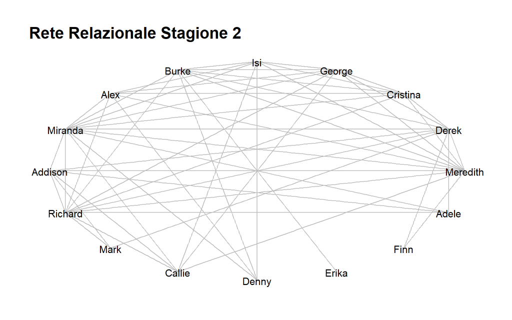

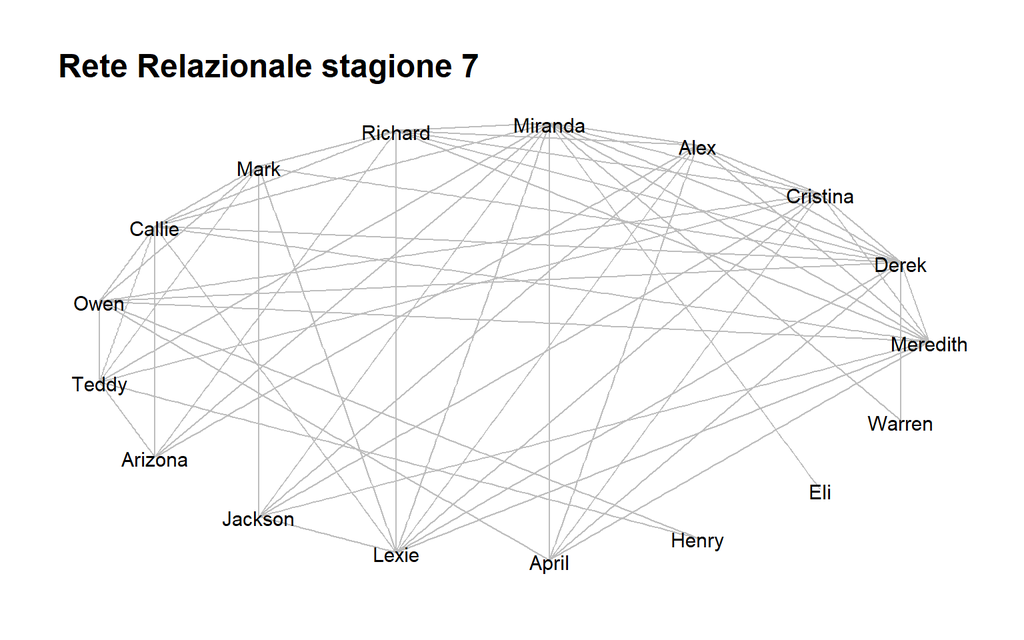

## Quali sono i personaggi che hanno un numero maggiore di relazioni? Quali sono i personaggi più influenti? Quali occupano una posizione centrale all’interno della rete relazionale?

L’analisi del grado mostra che Miranda Bailey è il personaggio con il maggior numero di relazioni dirette (12), seguita da Meredith Grey e Richard Webber (11). Questo risultato appare coerente con la struttura narrativa della seconda stagione.

In termini di influenza, Miranda Bailey corrisponde al personaggio più influente della rete. Ciò significa che Bailey non solo possiede numerose relazioni, ma è collegata a personaggi che a loro volta occupano posizioni importanti nella rete. Meredith e Richard presentano valori molto simili, confermando la loro rilevanza nella struttura narrativa.

La misura di closeness evidenzia ancora una volta Miranda Bailey come il personaggio più centrale della rete. L’analisi delle misure di centralità evidenzia come Miranda Bailey rappresenti il nodo più importante della rete relazionale della seconda stagione.

```
# A tibble: 16 × 4
   Nome     degree pagerank closeness
   <chr>     <dbl>    <dbl>     <dbl>
 1 Miranda      12   0.100     0.0556
 2 Meredith     11   0.0936    0.0526
 3 Richard      11   0.0933    0.0526
 4 Derek        10   0.0884    0.05
 5 Burke         9   0.0831    0.0476
 6 George        9   0.0758    0.0476
 7 Cristina      8   0.0682    0.0455
 8 Isi           8   0.0692    0.0435
 9 Addison       7   0.0632    0.0417
10 Alex          7   0.0610    0.0417
11 Callie        6   0.0531    0.04
12 Adele         4   0.0389    0.0370
13 Denny         4   0.0391    0.0357
14 Mark          3   0.0318    0.0333
15 Finn          2   0.0241    0.0333
16 Erika         1   0.0172    0.0286
```

## Quali sono i personaggi che fungono da intermediari tra i diversi personaggi?

I risultati ottenuti mostrano una forte centralizzazione della rete attorno ad alcuni personaggi chiave. In particolare, **Preston Burke** presenta il valore più alto di betweenness centrality (16.72), risultando il principale intermediario della rete. Nonostante non sia risultato uno tra i personaggi con maggior numero di relazioni, è evidente che risulta un nodo con la capacità di collegare storyline e gruppi narrativi distinti, dovuto anche dal suo collegamento con personaggi limitrofi nella rete.

```
# A tibble: 16 × 2
   Nome     betweenness
   <chr>          <dbl>
 1 Burke         16.7
 2 Derek         12.0
 3 Miranda       12.0
 4 Meredith      10.8
 5 Richard       10.7
 6 Addison        2.65
 7 Isi            2.50
 8 George         1.96
 9 Alex           1.63
10 Cristina       0.962
11 Callie         0.810
12 Denny          0.286
13 Mark           0
14 Erika          0
15 Finn           0
16 Adele          0
```

## Applicare diverse strategie di rimozione dei nodi per mettere alla prova la resilienza della rete relazionale.

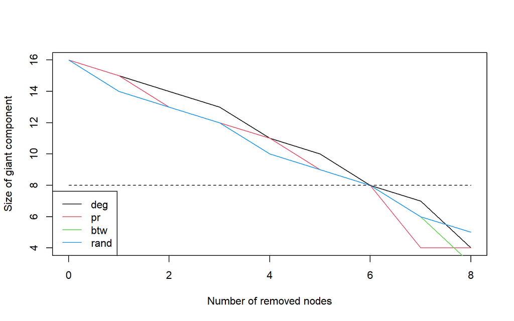

## Come sono cambiate le relazioni tra i personaggi e l’importanza di ogni personaggio tra la seconda e la settimana stagione? Nella settimana stagione esiste un personaggio che più influente del personaggio Meredith?

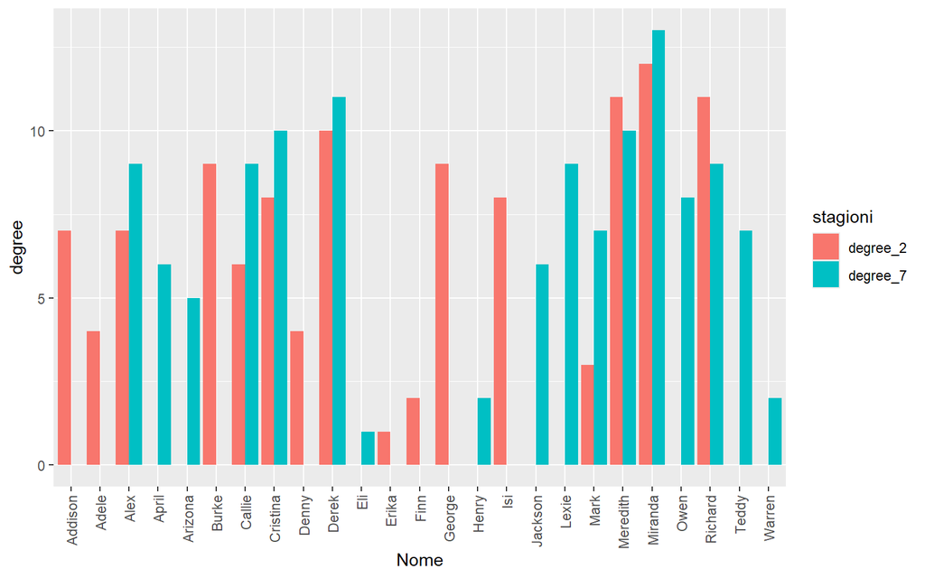

Un primo elemento che conferma questa differenza emerge dall’osservazione del degree, cioè del numero di legami diretti che ciascun personaggio intrattiene con gli altri. Nella seconda stagione i valori più alti si concentrano soprattutto su Miranda Bailey, Meredith Grey, Richard Webber, Derek Shepherd, Preston Burke, George O’Malley e Izzie Stevens.

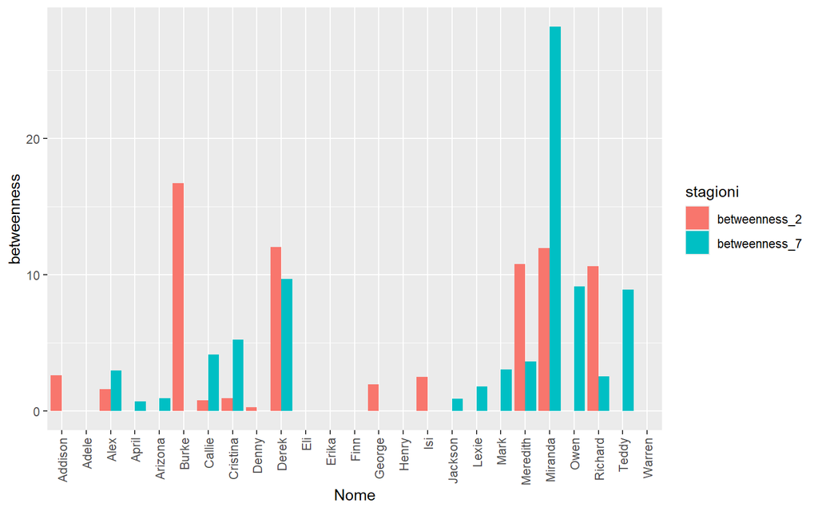

Nella seconda stagione la funzione di intermediazione è fortemente concentrata su pochi personaggi: in particolare Burke, Derek, Miranda, Meredith e Richard. Ciò indica una rete ancora fortemente polarizzata, nella quale alcuni nodi svolgono un ruolo decisivo nel connettere cluster differenti.

Nella settima stagione, al contrario, la betweenness si redistribuisce e mette in evidenza una rete più complessa. Il dato più rilevante è l’emergere di Miranda Bailey, che assume il ruolo di principale nodo di mediazione dell’intero sistema.

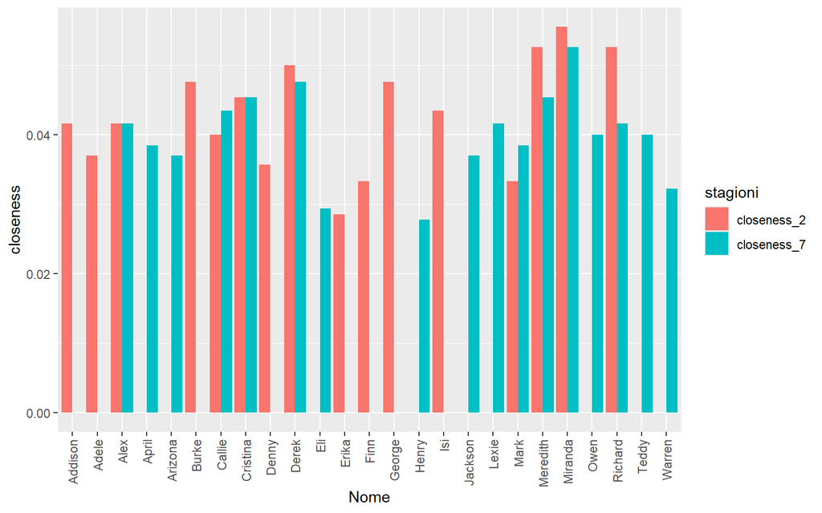

In questo caso le differenze tra le due stagioni risultano meno drastiche rispetto a quelle osservate per la betweenness, poiché in entrambe molte figure principali occupano posizioni prossime al centro del sistema. Tuttavia, anche qui si nota un’evoluzione significativa. Nella seconda stagione i valori più alti sembrano concentrarsi soprattutto su Miranda, Meredith, Richard, Derek e George.

Nella settima stagione la closeness resta elevata per i personaggi storici, ma si distribuisce su un numero maggiore di figure. Miranda e Meredith restano tra i nodi meglio posizionati; Derek e Richard mantengono un ruolo centrale all’interno della struttura ospedaliera; ma crescono anche personaggi come Cristina, Callie, Lexie, Mark e Teddy. La rete, dunque, diventa più distribuita senza per questo perdere compattezza: molti personaggi risultano infatti ben collocati e rapidamente raggiungibili.

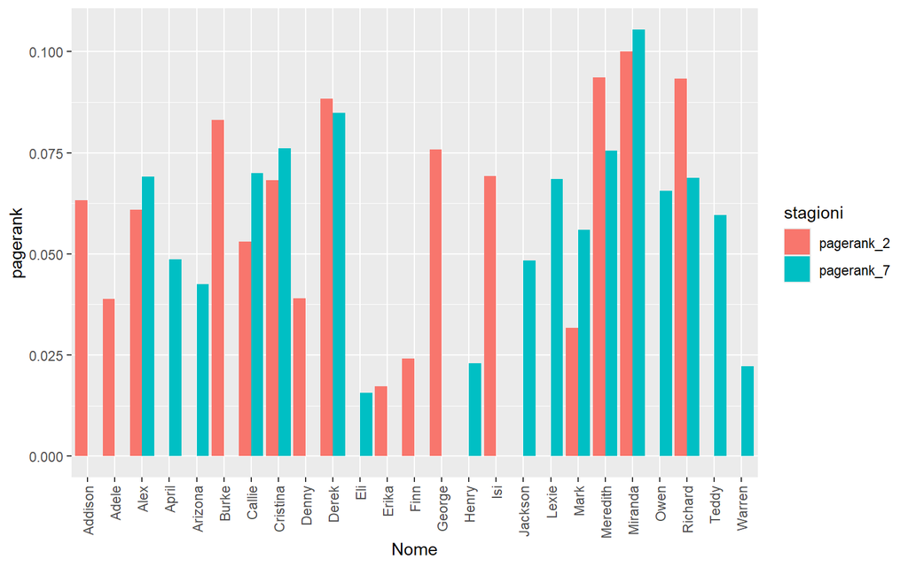

Un’ulteriore conferma di questa trasformazione proviene dal PageRank, che non misura soltanto il numero di legami di un personaggio, ma il fatto che tali legami sono connessi a nodi a loro volta forti e autorevoli. In termini narrativi, un PageRank elevato indica l’inserimento di un personaggio nel nucleo più prestigioso e influente della rete. Nella seconda stagione questo valore appare fortemente concentrato su Miranda, Meredith, Richard, Derek, Burke, George e Izzie.

## Quali tra i personaggi detiene all’interno della serie tv delle relazioni più intense?

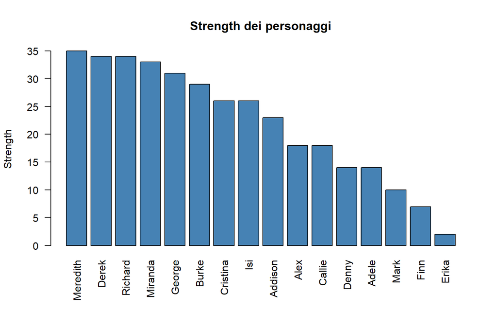

Meredith presenta la strength piu elevata perché nella seconda stagione costituisce il principale centro di condensazione relazionale: attorno a lei si intrecciano i legami affettivi, i conflitti sentimentali e le dinamiche quotidiane del gruppo degli specializzandi.

La posizione molto alta di Derek si spiega soprattutto con il fatto che nella seconda stagione si trova al centro della linea narrativa piu forte: quella con Meredith e Addison. Il triangolo relazionale lo rende costantemente coinvolto in scene ad alta intensita emotiva.

La posizione di Richard Webber è molto interessante, perche mostra che il peso relazionale non coincide solo con il melodramma amoroso.

## **Quali sono i personaggi più simili e dissimili tra loro utilizzando costrutti sulla similarità ed eterogeneità dei nodi? I personaggi Meredith e Cristina che sono migliori amiche sono i nodi più simili tra loro oppure vi è un altro personaggio che risulta più simile alla protagonista rispetto alla sua migliore amica? Mentre quale personaggio risulta nella rete quello più dissimile rispetto alla protagonista? Quali sono i primi 5 personaggi che possiedono relazioni con personaggi molto diversi tra loro?**

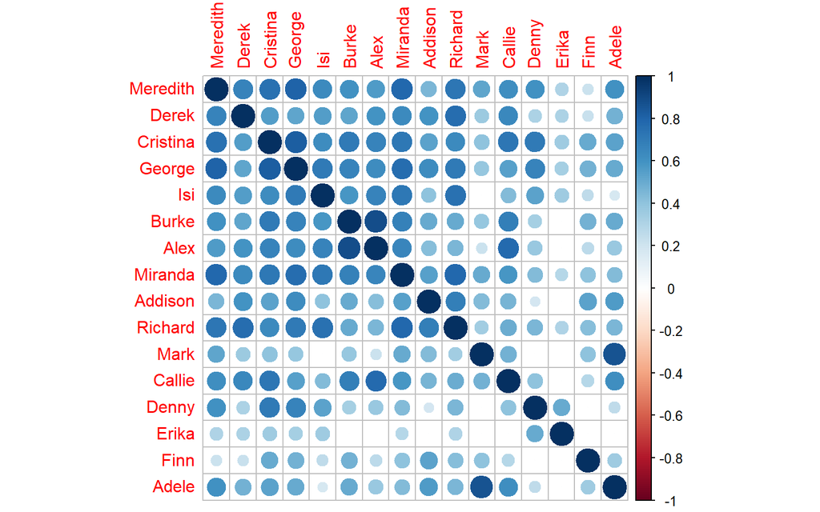

In particolare, una forte area di similarità sembra concentrarsi attorno al gruppo degli specializzandi formato da Meredith, Cristina, George, Izzie e Alex.

Questo risultato è plausibile perché questi personaggi condividono lo stesso spazio ospedaliero, sono inseriti nella medesima gerarchia formativa.

Accanto a questo primo blocco, un’altra somiglianza importante riguarda la coppia Meredith-Derek. Nella seconda stagione i due personaggi occupano infatti il centro di una delle principali linee narrative, cioè la relazione sentimentale complicata dalla presenza di Addison.

Un dato interessante riguarda il rapporto tra Meredith e Cristina. Sebbene siano legate da una delle amicizie più forti della serie e presentino certamente un’elevata similarità, non sembrano costituire la coppia più simile in assoluto.

```
       Nome distanza
1      Finn 3.316625
2   Addison 3.162278
3     Erika 3.162278
4     Burke 2.828427
5      Alex 2.828427
6      Mark 2.828427
7     Derek 2.645751
8       Isi 2.645751
9    Callie 2.645751
10    Denny 2.645751
11    Adele 2.645751
12  Richard 2.449490
13 Cristina 2.236068
14  Miranda 2.236068
15   George 2.000000
```

Sul versante opposto, il personaggio che risulta più dissimile rispetto a Meredith è Finn. Anche questo dato appare coerente dal punto di vista narrativo. Meredith è immersa in una rete densa, costruita attorno agli intern, ai medici strutturati più integrati nella vita del Seattle Grace e a relazioni segnate da prossimità quotidiana, gerarchie professionali e intrecci sentimentali complessi. Finn, invece, appartiene solo parzialmente a questo ecosistema: entra nella storia come figura relativamente periferica, legata soprattutto a Meredith e al triangolo con Derek.

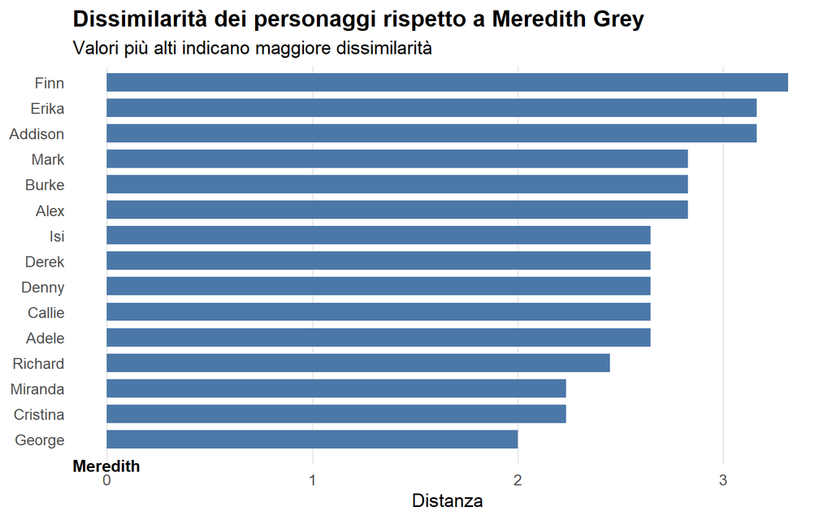

```
      Nome       rao
1    Derek 0.3954711
2  Miranda 0.3953294
3 Meredith 0.3800821
4  Richard 0.3785565
5    Burke 0.3678974
```

## **Quali personaggi sono inseriti soprattutto in relazioni positive? Quali sono maggiormente coinvolti in dinamiche conflittuali**? **Confrontando la rete di relazioni della stagione 2 con quella della stagione 7, come sono evoluti le tipologie di rapporti relazionali nel tempo?**

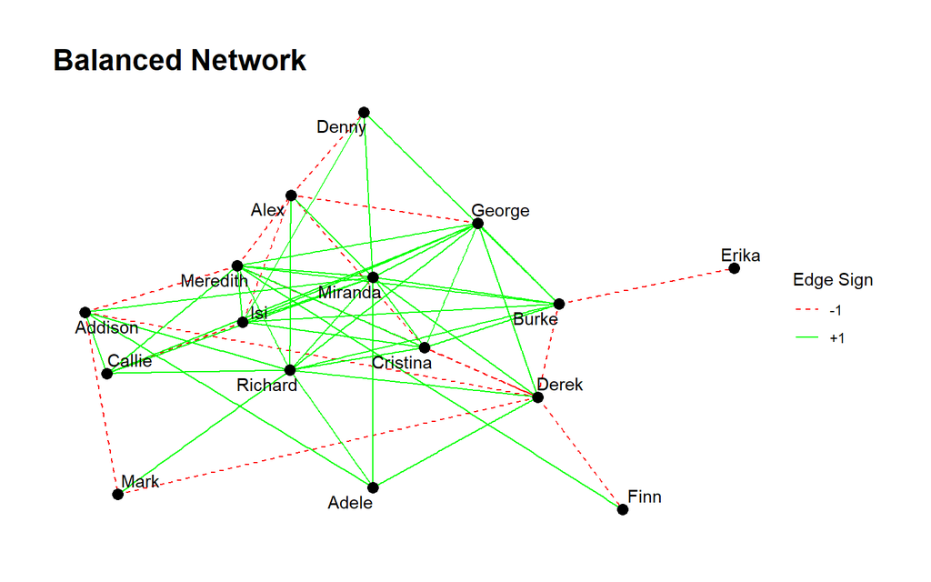

Nella stagione 2, uno dei personaggi con il massimo livello di coinvolgimento relazionale è Miranda Bailey. Il dato è coerente con la sua funzione narrativa: Bailey è un vero nodo della vita ospedaliera, costantemente coinvolta nei rapporti con gli specializzandi, con i superiori, con i casi clinici e con i conflitti professionali e disciplinari. La sua posizione la rende un punto di connessione tra autorità, controllo e tensione, e proprio per questo il suo profilo relazionale risulta estremamente denso. Accanto a lei, anche Richard Webber ottiene il valore massimo, in modo perfettamente coerente con il suo ruolo di capo del Seattle Grace e punto di riferimento istituzionale.

Diverso è il caso di Meredith, che mantiene un valore alto ma non massimo. Questo dato non implica una minore importanza narrativa, bensì suggerisce che, nella configurazione specifica delle relazioni signed, Meredith non sia il nodo più saturo di legami marcati.

```
       Nome       Due
1   Miranda 1.0000000
2   Richard 1.0000000
3     Adele 1.0000000
4    George 0.8888889
5    Callie 0.8333333
6     Burke 0.7777778
7  Cristina 0.7500000
8       Isi 0.7500000
9     Denny 0.7500000
10 Meredith 0.7272727
11  Addison 0.5714286
12     Finn 0.5000000
13    Derek 0.4000000
14     Mark 0.3333333
15     Alex 0.2857143
16    Erika 0.0000000
```

```
       Nome     Sette
1   Richard 1.0000000
2    Callie 1.0000000
3     Teddy 1.0000000
4   Arizona 1.0000000
5     Henry 1.0000000
6       Eli 1.0000000
7   Miranda 0.9230769
8     Derek 0.9090909
9     Lexie 0.8888889
10     Mark 0.8571429
11 Cristina 0.8000000
12     Alex 0.7777778
13     Owen 0.7500000
14 Meredith 0.7000000
15  Jackson 0.5000000
16    April 0.5000000
17   Warren 0.5000000
```

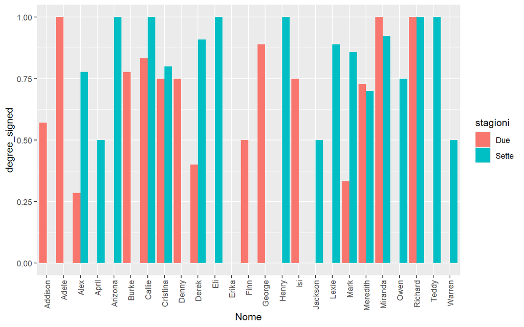

Il confronto con la stagione 7 mostra una trasformazione importante. Alcuni personaggi mantengono una posizione forte, ma il sistema nel suo complesso appare molto più distribuito. Richard, per esempio, conserva il valore massimo in entrambe le stagioni: si tratta di una continuità pienamente coerente con il suo ruolo di figura istituzionale stabile, che continua a fungere da punto di raccordo anche quando mutano i gruppi e le storyline. Miranda Bailey resta a sua volta molto alta, pur con una lieve flessione rispetto alla seconda stagione: questo non segnala una perdita di importanza, ma il fatto che nella settima stagione la sua funzione si colloca in una rete più ampia, nella quale anche altri personaggi occupano posizioni relazionali molto forti.

Tra i cambiamenti più evidenti spicca la crescita di Derek, che passa da una posizione relativamente circoscritta a un coinvolgimento molto più ampio. Nella settima stagione Derek non è più definito quasi soltanto dal triangolo amoroso con Meredith e Addison, ma è pienamente inserito in una rete estesa di rapporti professionali, affettivi e decisionali. Un incremento altrettanto netto riguarda Mark, che nella seconda stagione occupava ancora una posizione meno strutturata, mentre nella settima è ormai pienamente integrato nelle principali dinamiche dell’ospedale e nelle relazioni con personaggi centrali come Callie, Lexie e Derek. Anche Callie cresce fino a raggiungere il valore massimo: se nella seconda stagione era ancora una figura in ingresso, legata soprattutto a George, nella settima diventa un personaggio pienamente centrale, inserito in una rete affettiva e professionale molto articolata.

## **Quanto l’importanza della figura professionale del capo di chirurgia Richard coincide con la sua importanza all’interno della rete relazionale tra i personaggi? Rispetto alle diverse tipologie di relazioni conflittuali e non, di ogni personaggio, quanto ogni personaggio ha effettivamente un ruolo centrale nella rete?**

```
       nodi eig_cent_signed
1  Meredith      1.00000000
2     Derek      0.95054939
3  Cristina      0.94214339
4    George      0.92673240
5       Isi      0.89016367
6     Burke      0.84793138
7      Alex      0.77047851
8   Miranda      0.49533739
9   Addison      0.46576949
10  Richard      0.31965290
11     Mark      0.25312599
12   Callie      0.14801203
13    Denny      0.09463474
14    Erika     -0.02100412
15     Finn     -0.14241592
16    Adele     -0.33365577
```

L’analisi congiunta di degree ed eigenvector centrality mostra che, nella seconda stagione, la centralita istituzionale non coincide perfettamente con la centralita relazionale. Richard Webber è senza dubbio una figura fondamentale: è il capo di chirurgia, prende decisioni importanti, rappresenta l’autorita del Seattle Grace e orienta le traiettorie professionali di molti personaggi. Tuttavia, la rete narrativa della stagione 2 ruota soprattutto attorno a Meredith, Derek, Cristina, George, Izzie e Burke, cioè ai personaggi più direttamente coinvolti negli intrecci affettivi, amicali e conflittuali che strutturano la trama quotidiana. Richard occupa quindi una posizione più verticale che pienamente reticolare: ha autorita su molti, ma non partecipa con la stessa intensita al tessuto delle relazioni orizzontali che definiscono il cuore del gruppo.

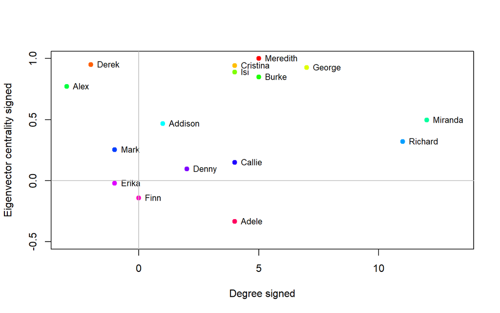

Il grafico permette di distinguere quattro profili principali. Il primo è quello dei personaggi molto centrali nella rete, collocati idealmente nella zona alta a destra: figure che hanno sia molti legami sia connessioni con nodi a loro volta molto centrali. In questo gruppo rientrano soprattutto Meredith, George, Cristina, Burke e Izzie.

Un secondo profilo riguarda i personaggi che hanno molte relazioni, ma che risultano meno immersi nel nucleo più denso delle interazioni reciproche tra protagonisti. Qui emergono soprattutto Miranda Bailey e Richard Webber. Il risultato è particolarmente interessante perché mostra come la loro importanza sia soprattutto istituzionale, gerarchica e professionale.

Un terzo profilo comprende i personaggi che risultano molto centrali dal punto di vista simbolico o narrativo, pur avendo una rete meno ampia. Il caso più evidente è quello di Derek, e in parte quello di Alex. Derek presenta infatti un eigenvector molto elevato, ma un degree non particolarmente alto: ciò significa che non è il personaggio con il maggior numero di relazioni diffuse, ma che i legami che possiede sono con nodi di grandissima importanza. È un risultato perfettamente coerente con la stagione 2, in cui Derek è soprattutto coinvolto in relazioni cruciali con Meredith e Addison e, attraverso queste, con il nucleo centrale del Seattle Grace.

Infine, il quarto profilo è quello dei personaggi periferici o poco integrati, collocabili in prossimità dell’origine o comunque lontani dal nucleo principale della rete. Tra questi si possono collocare Mark, Callie, Denny, Erika, Finn e Adele, mentre Addison occupa una posizione intermedia. In questi casi la centralita risulta più limitata o circoscritta. Mark è ancora relativamente periferico.

## **E’ possibile individuare delle comunità relazionali tra i personaggi della seconda stagione? Come variano le comunità individuate nella settimana stagione?**

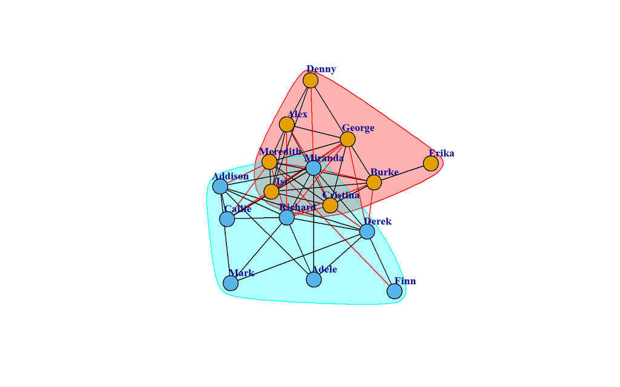

L’analisi del clustering mostra che la rete della seconda stagione si organizza attorno a due comunità principali che non corrispondono semplicemente a gruppi professionali, ma a due poli narrativi e relazionali distinti. Da un lato emerge un cluster legato al nucleo giovane, emotivo e orizzontale della stagione; dall’altro si riconosce un cluster più vicino alla gerarchia adulta, alle relazioni sentimentali mature e alle strutture esterne o superiori rispetto al gruppo degli intern. Questa divisione suggerisce che la seconda stagione sia ancora costruita su una tensione abbastanza leggibile tra il mondo della formazione e quello dell’autorità, tra la coralità dei giovani medici e la dimensione più istituzionale e adulta dell’ospedale.

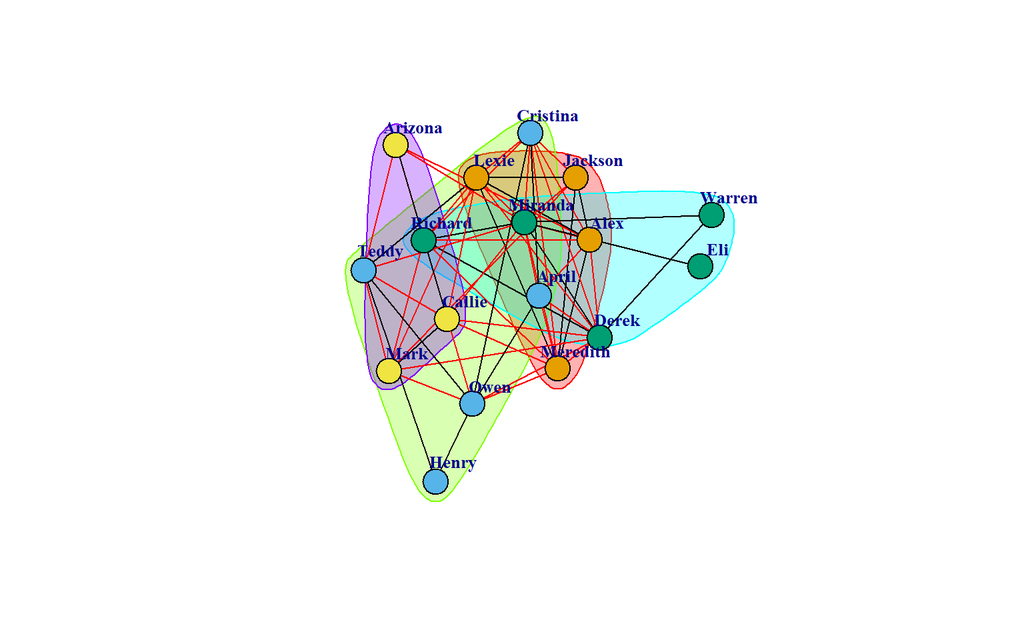

Se si passa alla settima stagione, il quadro cambia in modo netto. La rete non appare più bipolare come nella seconda, ma molto più articolata, policentrica e stratificata. I personaggi non si distribuiscono più in due soli blocchi riconoscibili, ma in più comunità parzialmente sovrapposte. Questo suggerisce che nella settima stagione le linee narrative siano più numerose, i personaggi più autonomi e le relazioni meno riducibili alla semplice opposizione tra giovani medici e figure senior. In altre parole, la rete non si regge più sul contrasto tra apprendisti e strutturati, ma su una pluralità di nuclei maturi interdipendenti.

## **Quali sono le parole che vengono utilizzate più frequentemente? Le parole maggiormente utilizzate sono coerenti con la trama trattata nella seconda stagione? Quali tipi di temi e sentimenti vengono trattati? Quali sono le parole maggiormente utilizzate che esprimono sentimenti positivi o negativi?**

[output not shown]

[output not shown]

[output not shown]

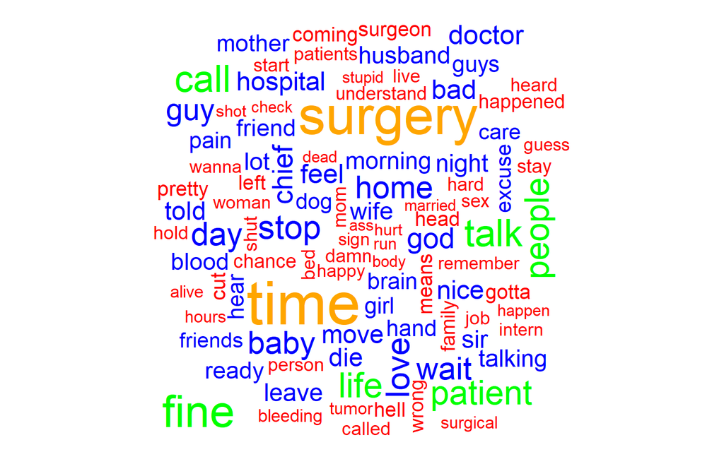

[output not shown]

[output not shown]

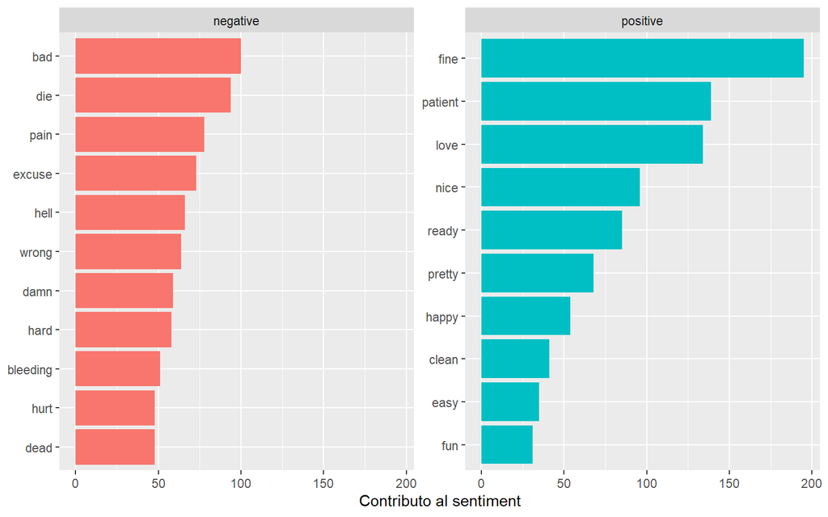

I grafici mostrano che, nella seconda stagione di *Grey’s Anatomy*, le parole con connotazione positiva più frequenti sono soprattutto fine, patient e love, mentre tra quelle negative emergono soprattutto bad, die e pain. Questo risultato è molto coerente con la struttura narrativa della stagione, che alterna continuamente due livelli: da un lato la dimensione affettiva e relazionale, dall’altro quella clinica e drammatica.

## Conclusioni

Il confronto tra la seconda e la settima stagione di *Grey’s Anatomy* evidenzia una significativa evoluzione della struttura della rete sociale dei personaggi, riflettendo i cambiamenti narrativi che caratterizzano la serie nel corso del tempo.

Nella seconda stagione la rete risulta fortemente concentrata attorno a pochi personaggi chiave.

La narrazione è ancora fortemente costruita intorno agli specializzandi originali e ai loro tutor, con una struttura relativamente gerarchica in cui pochi individui fungono da intermediari tra le diverse storyline.

Nella settima stagione, invece, la rete tende a diventare più articolata e distribuita. L’ingresso di nuovi personaggi e l’evoluzione dei rapporti professionali e personali determinano una maggiore complessità delle interazioni. Le relazioni non ruotano più esclusivamente attorno ai protagonisti originari, ma coinvolgono un numero maggiore di personaggi che assumono ruoli di rilievo nella rete. Di conseguenza, la funzione di collegamento tra i diversi gruppi narrativi viene condivisa da più nodi, rendendo la struttura complessiva meno dipendente da pochi individui.

Dal punto di vista narrativo, questo cambiamento riflette la maturazione della serie. Se nella seconda stagione il focus è principalmente sul percorso formativo degli specializzandi e sulle relazioni con i rispettivi supervisori, nella settima stagione molti di questi personaggi sono ormai medici affermati, con responsabilità professionali e personali che ampliano il numero e la varietà delle loro interazioni. Parallelamente, la presenza di nuovi chirurghi e di nuove dinamiche relazionali contribuisce a rendere la rete più ricca e interconnessa.